# Volunteer species identification: does training improve accuracy?

# 9. Sensitivity analyses

The model is refit under several alternative choices to see whether the training result depends on any of them.

```r
# Returns the training odds ratios (vs. level 1) with Wald 95% CIs and the
# likelihood-ratio p-value for training.
fit_scenario <- function(d, label,
                         fixed  = "training + master_gardener + year",
                         random = "(1 | vid) + (1 | true_species)") {
  d <- droplevels(d)
  f_full <- as.formula(paste("y ~", fixed, "+", random))
  f_null <- as.formula(paste("y ~", sub("^training \\+ ", "", fixed), "+", random))

  mf <- glmmTMB(f_full, data = d, family = binomial)
  mn <- glmmTMB(f_null, data = d, family = binomial)
  cf <- summary(mf)$coefficients$cond
  p_lrt <- anova(mn, mf)[["Pr(>Chisq)"]][2]

  or_ci <- function(term) {
    est <- cf[term, "Estimate"]; se <- cf[term, "Std. Error"]
    c(exp(est), exp(est - 1.96 * se), exp(est + 1.96 * se))
  }
  a <- or_ci("training2"); b <- or_ci("training3+")

  tibble(scenario = label, n_obs = nrow(d), n_vol = n_distinct(d$vid),
         or_2 = a[1], lo_2 = a[2], hi_2 = a[3],
         or_3plus = b[1], lo_3plus = b[2], hi_3plus = b[3],
         p_training = p_lrt)
}
```

```r
top_vid <- names(which.max(table(dat$vid)))          # volunteer with the most rows
flip_vids <- dat |>                                   # training differs within a year
  group_by(vid, year) |>
  summarise(k = n_distinct(training), .groups = "drop") |>
  filter(k > 1) |>
  pull(vid) |> as.character() |> unique()
bee_only <- dat |>                                    # drop fly and wasp true IDs
  filter(!str_detect(str_to_lower(correctid), "fly|flies|wasp"))

cat("Top volunteer:", top_vid, "(", sum(dat$vid == top_vid), "rows )\n")
```

```
## Top volunteer: 216 ( 592 rows )
```

```r
cat("Training-flip volunteers:", paste(flip_vids, collapse = ", "),
    "(", sum(dat$vid %in% flip_vids), "rows )\n")
```

```
## Training-flip volunteers: 191, 522 ( 14 rows )
```

```r
cat("Rows dropped for bees-only:", nrow(dat) - nrow(bee_only), "\n")
```

```
## Rows dropped for bees-only: 255
```

```r
results <- bind_rows(
  fit_scenario(dat, "Main model"),
  fit_scenario(filter(dat, vid != top_vid),
               paste0("Without top volunteer (", top_vid, ")")),
  fit_scenario(filter(dat, !vid %in% flip_vids),
               "Without training-flip volunteers"),
  fit_scenario(bee_only, "Bees only (no fly/wasp true IDs)"),
  fit_scenario(dat, "Species as fixed effect",
               fixed  = "training + master_gardener + year + true_species",
               random = "(1 | vid)")
) |>
  mutate(across(where(is.numeric), ~ round(.x, 3)))

write_csv(results, "output/sensitivity_summary.csv")
as.data.frame(results)
```

```
##                           scenario n_obs n_vol  or_2  lo_2  hi_2 or_3plus
## 1                       Main model  3369    86 1.055 0.715 1.558    1.251
## 2      Without top volunteer (216)  2777    85 1.034 0.702 1.523    1.123
## 3 Without training-flip volunteers  3355    84 1.086 0.734 1.609    1.278
## 4 Bees only (no fly/wasp true IDs)  3114    85 1.051 0.684 1.615    0.968
## 5          Species as fixed effect  3369    86 1.048 0.710 1.548    1.246
##   lo_3plus hi_3plus p_training
## 1    0.755    2.073      0.688
## 2    0.677    1.863      0.905
## 3    0.768    2.128      0.644
## 4    0.541    1.730      0.951
## 5    0.753    2.063      0.693
```

```r
#
```

# 10. GEE cross-check

A simpler population-averaged model with cluster-robust standard errors. GEE has no random effects, so species enters as a fixed effect.

```r
d_gee <- dat |> arrange(vid)     # geeglm needs rows sorted by cluster

gee_full <- geeglm(y ~ training + master_gardener + year + true_species,
                   id = vid, data = d_gee, family = binomial,
                   corstr = "exchangeable")
gee_null <- geeglm(y ~ master_gardener + year + true_species,
                   id = vid, data = d_gee, family = binomial,
                   corstr = "exchangeable")

cf <- summary(gee_full)$coefficients
gee_tab <- data.frame(term = rownames(cf),
                      OR = exp(cf$Estimate),
                      lo = exp(cf$Estimate - 1.96 * cf$Std.err),
                      hi = exp(cf$Estimate + 1.96 * cf$Std.err),
                      p  = cf[["Pr(>|W|)"]])
gee_tab[, 2:5] <- round(gee_tab[, 2:5], 3)
write_csv(gee_tab, "output/gee_summary.csv")
gee_tab
```

```
##                             term    OR    lo     hi     p
## 1                    (Intercept) 3.732 1.207 11.539 0.022
## 2                      training2 0.943 0.607  1.462 0.792
## 3                     training3+ 1.353 0.774  2.364 0.289
## 4                master_gardener 0.599 0.379  0.947 0.028
## 5                       year2024 1.729 0.988  3.025 0.055
## 6                       year2025 2.047 1.341  3.124 0.001
## 7         true_speciesBumbleBees 8.636 2.550 29.247 0.001
## 8  true_speciesGreenMetallicBees 3.485 1.061 11.447 0.040
## 9     true_speciesHairyBellyBees 0.591 0.208  1.681 0.324
## 10      true_speciesHairyLegBees 0.683 0.225  2.071 0.500
## 11         true_speciesHoneyBees 4.219 1.589 11.197 0.004
## 12          true_speciesMultiple 0.743 0.233  2.364 0.615
## 13             true_speciesOther 0.181 0.043  0.754 0.019
## 14  true_speciesStripedSweatBees 0.490 0.180  1.334 0.163
## 15      true_speciesSyrphidFlies 0.529 0.177  1.583 0.255
## 16      true_speciesTinyDarkBees 1.119 0.425  2.950 0.820
## 17             true_speciesWasps 0.439 0.144  1.337 0.147
```

Wald test for training (both levels together):

```r
anova(gee_null, gee_full)
```

```
## Analysis of 'Wald statistic' Table
##
## Model 1 y ~ training + master_gardener + year + true_species
## Model 2 y ~ master_gardener + year + true_species
##   Df     X2 P(>|Chi|)
## 1  2 1.2951    0.5233
```

# 11. Does a volunteer’s number of observations relate to accuracy?

Two different questions:

- **Learning curve (within a person):** does accuracy rise as a volunteer submits more observations? (`log2_prior`)
- **Prolific vs. occasional volunteers (between people):** are volunteers who submit more overall more accurate? (`log2_total`)

Both are on a log2 scale, so each odds ratio is **per doubling** of observations.

```r
bins <- c(-1, 4, 19, 49, 99, 199, Inf)
labs <- c("0-4", "5-19", "20-49", "50-99", "100-199", "200+")

# Mixes within-person learning with differences between people, and few volunteers contribute to the highest bins.
dat |>
  mutate(prior_bin = cut(n_prior, breaks = bins, labels = labs)) |>
  group_by(prior_bin) |>
  summarise(n = n(), volunteers = n_distinct(vid),
            accuracy = round(mean(y), 3))
```

```
## # A tibble: 6 × 4
##   prior_bin     n volunteers accuracy
##   <fct>     <int>      <int>    <dbl>
## 1 0-4         336         85    0.851
## 2 5-19        606         59    0.847
## 3 20-49       707         34    0.898
## 4 50-99       534         19    0.908
## 5 100-199     547          9    0.914
## 6 200+        639          4    0.936
```

```r
  # accuracy trends updwards with more prior observations, but the highest bin has few volunteers
  # adding experience to the model moves the training estimates toward no effect.
  # i.e. the data can't fully separate "volunteers learn as they go" from "volunteers who keep submitting are better"

  # tl;dr: each doubling of earlier observations raises the odds of a correct ID by about 15% (odds ratio ~ 1.15).
```

```r
f_base  <- y ~ training + master_gardener + year + (1 | vid) + (1 | true_species)
f_learn <- y ~ training + master_gardener + year + log2_prior + (1 | vid) + (1 | true_species)
f_total <- y ~ training + master_gardener + year + log2_total + (1 | vid) + (1 | true_species)
f_both  <- y ~ training + master_gardener + year + log2_prior + log2_total +
             (1 | vid) + (1 | true_species)

m_base  <- glmmTMB(f_base,  data = dat, family = binomial)
m_learn <- glmmTMB(f_learn, data = dat, family = binomial)
m_total <- glmmTMB(f_total, data = dat, family = binomial)
m_both  <- glmmTMB(f_both,  data = dat, family = binomial)

AIC(m_base, m_learn, m_total, m_both)   # lower = better fit
```

```
##         df      AIC
## m_base   8 1972.077
## m_learn  9 1964.378
## m_total  9 1965.460
## m_both  10 1964.469
```

```r
# both terms (log2_prior and log2_total) improve the model fit with an AIC of 1964.4 and 1965.5 vs 1972.1 without either.
```

Likelihood-ratio tests:

```r
cat("Learning curve (adds log2_prior):\n");      anova(m_base, m_learn)
```

```
## Learning curve (adds log2_prior):
```

```
## Data: dat
## Models:
## m_base: y ~ training + master_gardener + year + (1 | vid) + (1 | true_species), zi=~0, disp=~1
## m_learn: y ~ training + master_gardener + year + log2_prior + (1 | vid) + , zi=~0, disp=~1
## m_learn:     (1 | true_species), zi=~0, disp=~1
##         Df    AIC    BIC  logLik deviance  Chisq Chi Df Pr(>Chisq)
## m_base   8 1972.1 2021.1 -978.04   1956.1
## m_learn  9 1964.4 2019.5 -973.19   1946.4 9.6989      1   0.001844 **
## ---
## Signif. codes:  0 '***' 0.001 '**' 0.01 '*' 0.05 '.' 0.1 ' ' 1
```

```r
cat("Prolific volunteers (adds log2_total):\n"); anova(m_base, m_total)
```

```
## Prolific volunteers (adds log2_total):
```

```
## Data: dat
## Models:
## m_base: y ~ training + master_gardener + year + (1 | vid) + (1 | true_species), zi=~0, disp=~1
## m_total: y ~ training + master_gardener + year + log2_total + (1 | vid) + , zi=~0, disp=~1
## m_total:     (1 | true_species), zi=~0, disp=~1
##         Df    AIC    BIC  logLik deviance  Chisq Chi Df Pr(>Chisq)
## m_base   8 1972.1 2021.1 -978.04   1956.1
## m_total  9 1965.5 2020.6 -973.73   1947.5 8.6171      1    0.00333 **
## ---
## Signif. codes:  0 '***' 0.001 '**' 0.01 '*' 0.05 '.' 0.1 ' ' 1
```

```r
cat("Learning, after allowing for total:\n");    anova(m_total, m_both)
```

```
## Learning, after allowing for total:
```

```
## Data: dat
## Models:
## m_total: y ~ training + master_gardener + year + log2_total + (1 | vid) + , zi=~0, disp=~1
## m_total:     (1 | true_species), zi=~0, disp=~1
## m_both: y ~ training + master_gardener + year + log2_prior + log2_total + , zi=~0, disp=~1
## m_both:     (1 | vid) + (1 | true_species), zi=~0, disp=~1
##         Df    AIC    BIC  logLik deviance  Chisq Chi Df Pr(>Chisq)
## m_total  9 1965.5 2020.6 -973.73   1947.5
## m_both  10 1964.5 2025.7 -972.23   1944.5 2.9907      1    0.08375 .
## ---
## Signif. codes:  0 '***' 0.001 '**' 0.01 '*' 0.05 '.' 0.1 ' ' 1
```

Odds ratios. The training rows show whether the training estimate changes once experience is accounted for.

```r
or_row <- function(mod, term, label) {
  cf  <- summary(mod)$coefficients$cond
  est <- cf[term, "Estimate"]; se <- cf[term, "Std. Error"]
  tibble(model = label, term = term,
         odds_ratio = exp(est), lo = exp(est - 1.96 * se), hi = exp(est + 1.96 * se),
         p = cf[term, "Pr(>|z|)"])
}

exp_results <- bind_rows(
  or_row(m_learn, "log2_prior", "Learning curve"),
  or_row(m_total, "log2_total", "Prolific volunteers"),
  or_row(m_both,  "log2_prior", "Both in model"),
  or_row(m_both,  "log2_total", "Both in model"),
  or_row(m_base,  "training3+", "Training 3+ vs 1 (no experience term)"),
  or_row(m_learn, "training3+", "Training 3+ vs 1 (with learning curve)"),
  or_row(m_both,  "training3+", "Training 3+ vs 1 (with both)"),
  or_row(m_base,  "training2",  "Training 2 vs 1 (no experience term)"),
  or_row(m_learn, "training2",  "Training 2 vs 1 (with learning curve)"),
  or_row(m_both,  "training2",  "Training 2 vs 1 (with both)")
) |> mutate(across(where(is.numeric), ~ round(.x, 3)))

write_csv(exp_results, "output/experience_summary.csv")
as.data.frame(exp_results)
```

```
##                                     model       term odds_ratio    lo    hi
## 1                          Learning curve log2_prior      1.150 1.058 1.250
## 2                     Prolific volunteers log2_total      1.208 1.071 1.363
## 3                           Both in model log2_prior      1.099 0.989 1.222
## 4                           Both in model log2_total      1.111 0.956 1.292
## 5   Training 3+ vs 1 (no experience term) training3+      1.251 0.755 2.073
## 6  Training 3+ vs 1 (with learning curve) training3+      1.065 0.666 1.701
## 7            Training 3+ vs 1 (with both) training3+      1.008 0.627 1.620
## 8    Training 2 vs 1 (no experience term)  training2      1.055 0.715 1.558
## 9   Training 2 vs 1 (with learning curve)  training2      0.929 0.634 1.361
## 10            Training 2 vs 1 (with both)  training2      0.946 0.646 1.386
##        p
## 1  0.001
## 2  0.002
## 3  0.079
## 4  0.169
## 5  0.385
## 6  0.794
## 7  0.974
## 8  0.786
## 9  0.704
## 10 0.776
```

```r
# learning curve: odds ratio = 1.15 (95% CI: 1.06-1.25), p = 0.001
# prolific volunteers: odds ratio = 1.21 (95% CI: 1.07-1.36), p = 0.002

# the slight gain for level 3+ training disappears once experience was accounted for; essentially, the slight benefit of training disappears when experience is in the model.
# this isn't necessarily meaningful, because the training levels are confounded with experience.
```

Predicted accuracy by earlier observations. Read the **shape** of the curve: the level describes a typical volunteer and species, not overall accuracy.

```r
at_vals <- c(0, 4, 9, 19, 49, 99, 199, 399)   # earlier observations

pred <- emmeans(m_learn, ~ log2_prior,
                at = list(log2_prior = log2(at_vals + 1)), type = "response") |>
  as.data.frame() |>
  mutate(prior_obs = round(2^log2_prior - 1))

pred |> select(prior_obs, prob, asymp.LCL, asymp.UCL) |>
  mutate(across(where(is.numeric), ~ round(.x, 3)))
```

```
##   prior_obs  prob asymp.LCL asymp.UCL
## 1         0 0.760     0.605     0.867
## 2         4 0.814     0.691     0.896
## 3         9 0.834     0.721     0.907
## 4        19 0.853     0.748     0.919
## 5        49 0.874     0.778     0.933
## 6        99 0.889     0.796     0.942
## 7       199 0.902     0.813     0.951
## 8       399 0.914     0.827     0.959
```

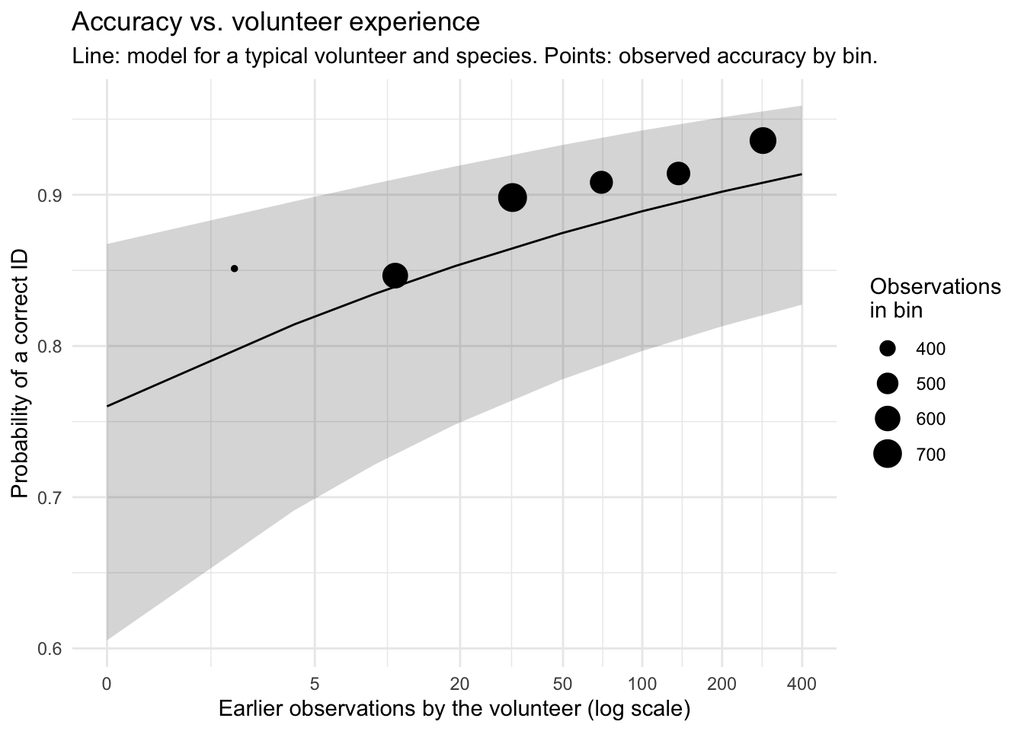

```r
obs_bins <- dat |>
  mutate(prior_bin = cut(n_prior, breaks = bins, labels = labs)) |>
  group_by(prior_bin) |>
  summarise(mid = median(n_prior), acc = mean(y), n = n(), .groups = "drop")

brks <- c(0, 5, 20, 50, 100, 200, 400)
p <- ggplot(pred, aes(log2_prior, prob)) +
  geom_ribbon(aes(ymin = asymp.LCL, ymax = asymp.UCL), alpha = 0.2) +
  geom_line() +
  geom_point(data = obs_bins, aes(log2(mid + 1), acc, size = n), inherit.aes = FALSE) +
  scale_x_continuous(breaks = log2(brks + 1), labels = brks) +
  labs(x = "Earlier observations by the volunteer (log scale)",
       y = "Probability of a correct ID",
       size = "Observations\nin bin",
       title = "Accuracy vs. volunteer experience",
       subtitle = "Line: model for a typical volunteer and species. Points: observed accuracy by bin.") +
  theme_minimal()

ggsave("output/experience_curve.png", p, width = 7.5, height = 4.8, dpi = 200)
p
```

Robustness: the learning-curve effect without the volunteer who contributes the most rows.

```r
m_learn_notop <- glmmTMB(f_learn, data = filter(dat, vid != top_vid), family = binomial)
or_row(m_learn_notop, "log2_prior", "Without top volunteer") |>
  mutate(across(where(is.numeric), ~ round(.x, 3)))
```

```
## # A tibble: 1 × 6
##   model                 term       odds_ratio    lo    hi     p
##   <chr>                 <chr>           <dbl> <dbl> <dbl> <dbl>
## 1 Without top volunteer log2_prior       1.14  1.04  1.24 0.003
```

```r
# learning curve effect is still present without the top volunteer: odds ratio = 1.14 (95% CI: 1.04-1.24), p = 0.003
```

Exploratory: do volunteers differ in how fast they improve (a random slope for experience)? This can fail to converge with few observations per volunteer, which is informative in itself.

```r
m_slope <- try(
  glmmTMB(y ~ training + master_gardener + year + log2_prior +
            (1 + log2_prior | vid) + (1 | true_species),
          data = dat, family = binomial),
  silent = TRUE)

if (inherits(m_slope, "try-error")) {
  cat("The random-slope model did not fit; skip it.\n")
} else if (!isTRUE(m_slope$sdr$pdHess)) {
  cat("The random-slope model fit but did not converge cleanly; do not interpret it.\n")
} else {
  print(VarCorr(m_slope))
  anova(m_learn, m_slope)
}
```

```
##
## Conditional model:
##  Groups       Name        Std.Dev. Corr
##  vid          (Intercept) 0.94087
##               log2_prior  0.12749  -0.840
##  true_species (Intercept) 1.08171
```

```
## Data: dat
## Models:
## m_learn: y ~ training + master_gardener + year + log2_prior + (1 | vid) + , zi=~0, disp=~1
## m_learn:     (1 | true_species), zi=~0, disp=~1
## m_slope: y ~ training + master_gardener + year + log2_prior + (1 + log2_prior | , zi=~0, disp=~1
## m_slope:     vid) + (1 | true_species), zi=~0, disp=~1
##         Df    AIC    BIC  logLik deviance  Chisq Chi Df Pr(>Chisq)
## m_learn  9 1964.4 2019.5 -973.19   1946.4
## m_slope 11 1966.6 2034.0 -972.32   1944.6 1.7458      2     0.4177
```

```r
# model converges; volunteer-to-volunteer variation in learning curve is small, and allowing it doesn't improve the fit.
# aka no evidence that volunteers differ in how fast they improve.
```